# Assignment 3: Suggested Solutions & Feedback

Author

ETF3231/5231

Read and tidy up the data using previous code.

> For the tasks that follow you will be modelling the original data without any transformation performed (even if you previously deemed it necessary). For questions 1 to 5 use the training data, i.e., ignore the last two years of your data.

# Question 1

> Plot your time series. By observing the plot and describing its components select an ETS model you think is appropriate for forecasting. Make sure you justify your choice (no more than 150 words). (8 marks)

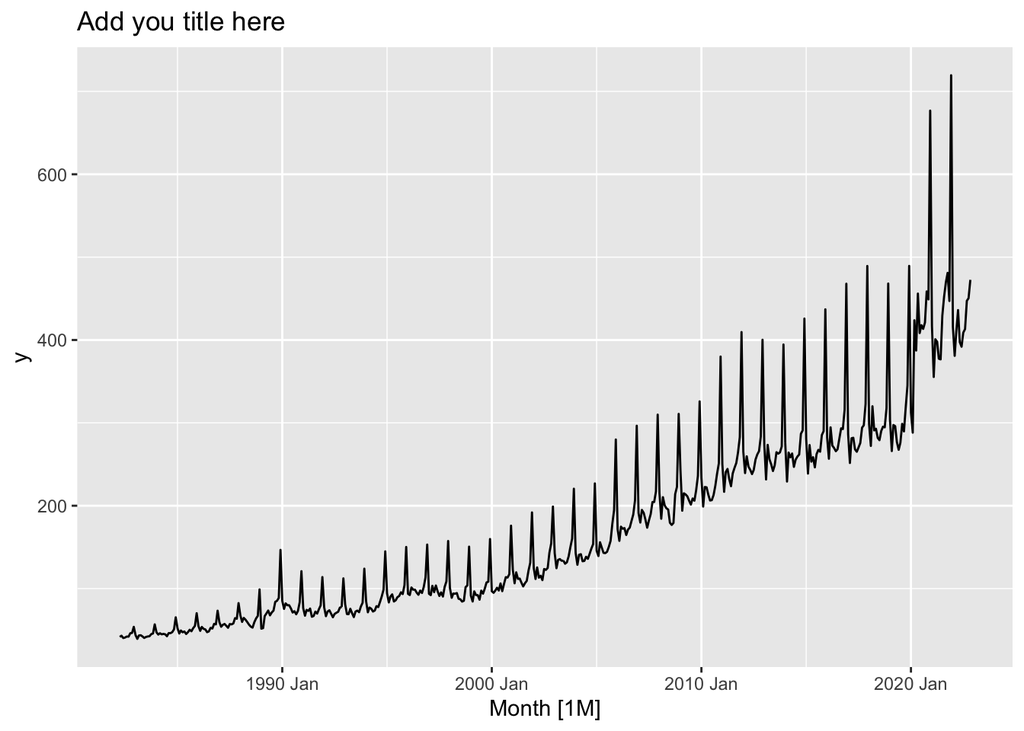

```r
myts %>% autoplot(y) +
  labs(title ="Add you title here",
       lab="add y label")
```

Marking guide:

- Plot: labels, units and heading. (1m)
- Choose an ETS model (1m)
- Justify the choice for trend (damped or not). (2m)
- Justify the choice for seasonal. (2m)
- Justify the choice for error. (2m)
- -2: Exceeding word limit.

Expectation:

- Plot the time series (with labels, units and heading).
- Select an ETS model.
- Justify your choice for trend (damped or not), seasonal and error components.

Sample answer:

Common mistakes:

- decompose the series is not needed for the justification of the model
- do not attempt to run the ETS model, use own judgement by looking at the time series itself.

# Question 2

> Estimate the ETS model you described in Question 1 and show the estimated model output. Describe and comment on the estimated parameters and components. Include any plots you see necessary (no more than 150 words). (14 marks)

```r
ETS_MAdM <- myts %>% model(ETS(y ~ error("M")+trend("Ad")+season("M")))

options(digits=4)

ETS_MAdM %>% report()
```

```
Series: y
Model: ETS(M,Ad,M)
  Smoothing parameters:
    alpha = 0.5422
    beta  = 0.0102
    gamma = 0.07806
    phi   = 0.98

  Initial states:
  l[0]     b[0]   s[0]  s[-1] s[-2] s[-3] s[-4] s[-5]  s[-6]  s[-7]  s[-8]
 43.58 -0.01013 0.9789 0.8911 1.006 1.449 1.066 1.019 0.9472 0.9305 0.9065
  s[-9] s[-10] s[-11]
 0.8978 0.9489 0.9591

  sigma^2:  0.0028

 AIC AICc  BIC
4960 4962 5036
```

```r
#or
ETS_MAdM %>% tidy() %>% select(-.model)
```

```
# A tibble: 18 × 2
   term   estimate
   <chr>     <dbl>
 1 alpha    0.542
 2 beta     0.0102
 3 gamma    0.0781
 4 phi      0.980
 5 l[0]    43.6
 6 b[0]    -0.0101
 7 s[0]     0.979
 8 s[-1]    0.891
 9 s[-2]    1.01
10 s[-3]    1.45
11 s[-4]    1.07
12 s[-5]    1.02
13 s[-6]    0.947
14 s[-7]    0.931
15 s[-8]    0.907
16 s[-9]    0.898
17 s[-10]   0.949
18 s[-11]   0.959
```

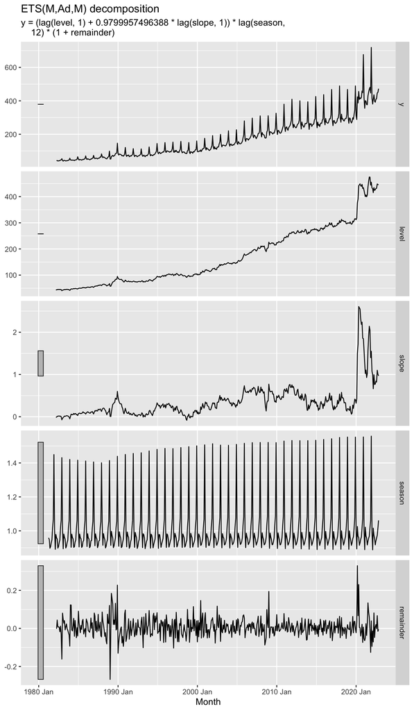

```r
ETS_MAdM %>% components() %>%  autoplot()
```

Marking guide:

- Estimated model output (3m)
- Plot the estimated states (2m)
- Recognise that initial states are also estimated. (1m)
- Comment on the smoothing parameters and relate the estimated smoothing coefficients with the plot (8m = 2 + 3 + 3 for each level, trend, seas)
- -1: Exceeding word limit.

Expectation:

- Show the estimated model output.
- Comment on the estimated smoothing parameters.
- Recognise that initial states are also estimated.
- Plot the estimated states.
- Comment on how the estimated smoothing coefficients relate to plots these.

# Question 3

> Plot the residuals from the model and comment on these (no more than 50 words). Perform some diagnostic checks and comment on whether you are satisfied with the fit of the model. (Make sure you state all relevant information for any hypothesis test you perform such as the null hypothesis, the degrees of freedom, the decision, etc.). (10 marks)

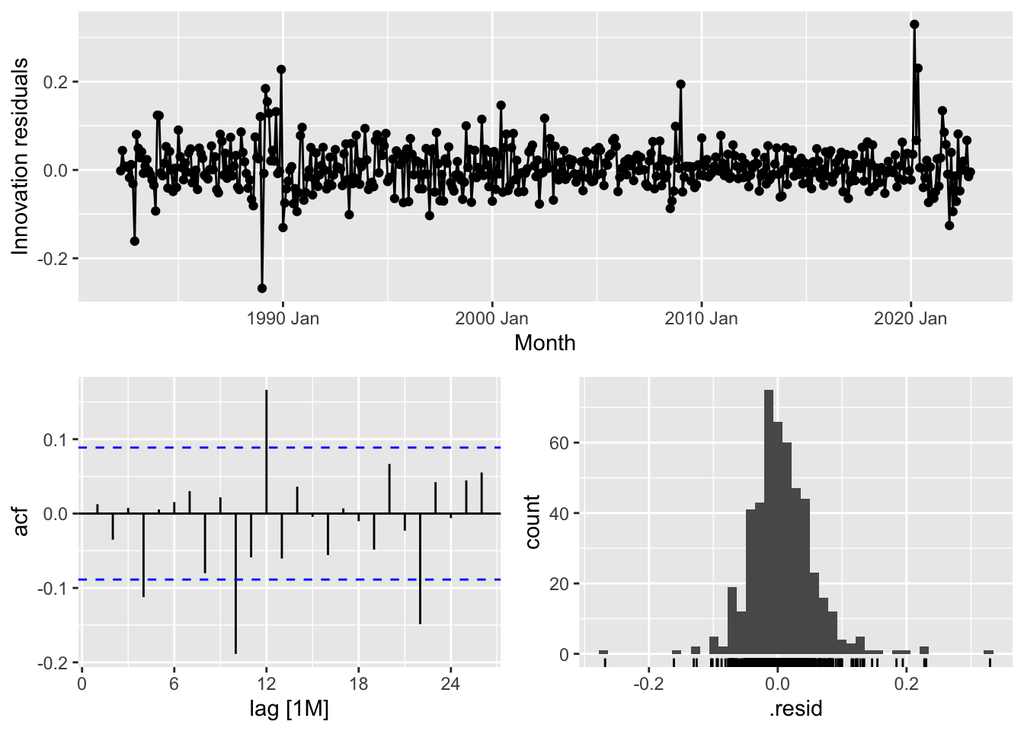

```r
ETS_MAdM %>% gg_tsresiduals()
```

```r
augment(ETS_MAdM) %>% features(.innov, ljung_box, lag=24, dof=17)
```

```
# A tibble: 1 × 3
  .model                                                  lb_stat lb_pvalue
  <chr>                                                     <dbl>     <dbl>
1 "ETS(y ~ error(\"M\") + trend(\"Ad\") + season(\"M\"))"    64.6  1.82e-11
```

Marking guide:

- Plot/Comment on the residuals (2m)
- Plot/Comment on the histogram of the residuals (2m)
- Plot/Comment on the ACF plot (2m)
- Perform LB test (1m), with the hypothesis (1m) and correct df (1m) and comment on the result (1m)
- -1: Exceeding word limit.

Expectation:

- Plot the residuals and comment.
- Plot the histogram and comment.
- Plot the ACF and comment.
- State the null hypothesis and perform a Ljung-Box test and comment.
- Comment on whether you are satisfied with the fit of the model.

Common errors:

# Question 4

> Let R select an ETS model. What model has been chosen and how has this model been chosen? (No more than 100 words). (6 marks)

```r
ETS_auto <- myts %>%  model(ETS(y))

ETS_auto %>% report()
```

```
Series: y
Model: ETS(M,A,M)
  Smoothing parameters:
    alpha = 0.4515
    beta  = 0.005397
    gamma = 0.0812

  Initial states:
  l[0]    b[0]   s[0]  s[-1] s[-2] s[-3] s[-4] s[-5] s[-6]  s[-7]  s[-8]  s[-9]
 44.66 0.02682 0.9823 0.8902 1.007 1.446  1.06 1.026 0.952 0.9372 0.9028 0.8941
 s[-10] s[-11]
 0.9409 0.9614

  sigma^2:  0.0028

 AIC AICc  BIC
4960 4961 5031
```

Marking guide:

- State the chosen model (2m)
- Explain how the model is obtained (1m)
- The model is selected based on smallest AICc (2m) and excludes unstable models (1m)

Expectation:

- State the model.
- How has this model been chosen? The ets function returns the model with the smallest AICc.
- Without restrictions, the ETS() function fits all possible combinations and returns the model with the smallest AICc. However, the ETS function is restricted by default and excludes unstable models.

# Question 5

> Comment on how the model chosen by R is different to the model you have specified (no more than 50 words). Which of the two models would you choose and why? (no more than 50 words). (Hint: think about model selection here but also check your residuals).

> If the models are identical specify a plausible alternative. Give a brief justification for your choice (no more than 100 words). (Hint: also check the residuals from this model). (12 marks)

Marking guide:

- Comment on how two models are different (different alpha, gamma or other characteristics. (6m)
- State the selected model and why (min AICc). (1m)
- Discuss the chosen model (5m)
  - visualise residual plot 1
  - comment the residual plot 1
  - ACF 1
  - histogram 1
  - LB test 1
- state the predictive accuracy (1m)
- -1: Exceeding word limit
- -0.5: Incorrect interpretation

Detail breakdown:  
0-1.5 -> no explanantion  
2 -> Unaccecptable explanation  
3 -> Inadequate explanation  
4 -> Interesting explanation  
+2 -> with the comment upon coefficients

Expectation if the models are different:

- Comment on how two models are different.
- The chosen model.
- The reason for choosing the best model.
- Check the residuals (a brief discussion on the residual plot and ACF – histogram and Ljung-Box).

Expectation if the models are identical:

- Specify a plausible alternative.
- The chosen model.
- The reason for choosing the best model.
- Check the residuals (a brief discussion on the residual plot and ACF – histogram and Ljung-Box test).

```r
ETS_alt <- myts %>%  model(ETS(y ~ error("M")+trend("N")+season("M")))
ETS_alt %>% report()
```

```
Series: y
Model: ETS(M,N,M)
  Smoothing parameters:
    alpha = 0.5179
    gamma = 0.059

  Initial states:
  l[0]   s[0]  s[-1] s[-2] s[-3] s[-4] s[-5]  s[-6]  s[-7]  s[-8] s[-9] s[-10]
 50.57 0.9858 0.8962 1.008 1.461  1.06 1.009 0.9402 0.9208 0.9131 0.905 0.9519
 s[-11]
 0.9487

  sigma^2:  0.0028

 AIC AICc  BIC
4971 4972 5033
```

Which of the two models would you choose?

- This is not a subjective choice. Select the model with the minimum AICc rather than the one with the minimum forecast accuracy measures.
- Since both models are in the same ETS family, AICc can be used to compare the models. Remember the advantage of using an information criterion such as the AICc is that it uses all the data and not just a small test sample that the forecast accuracy measures such as RMSE (unless something has gone obviously wrong which is rarely the case).

# Question 6

> Generate forecasts for the last two years of your sample using both alternative ETS models (you will need to re-estimate both models over the appropriate training sample). Plot the forecasts and forecast intervals. Briefly comment on these. Which model does best? (No more than 100 words). (8 marks)

```r
myts_train <- myts %>%
  slice(1:(n() - 24))

ETS_train_fit <- myts_train %>%
  model(ETS_MAdM=ETS(y~error("M")+trend("Ad")+season("M")),
        ETS_MNM=ETS(y~error("M")+trend("N")+season("M"))                                 )
ETS_train_fit %>% tidy() %>%
  pivot_wider(names_from=.model,values_from=estimate)
```

```
# A tibble: 18 × 3
   term    ETS_MAdM   ETS_MNM
   <chr>      <dbl>     <dbl>
 1 alpha   0.474     0.454
 2 beta    0.0124   NA
 3 gamma   0.000100  0.000100
 4 phi     0.974    NA
 5 l[0]   43.9      48.4
 6 b[0]    0.131    NA
 7 s[0]    0.986     0.993
 8 s[-1]   0.888     0.890
 9 s[-2]   1.00      1.00
10 s[-3]   1.49      1.50
11 s[-4]   1.05      1.05
12 s[-5]   1.00      1.00
13 s[-6]   0.945     0.944
14 s[-7]   0.930     0.925
15 s[-8]   0.909     0.908
16 s[-9]   0.898     0.893
17 s[-10]  0.943     0.940
18 s[-11]  0.955     0.957
```

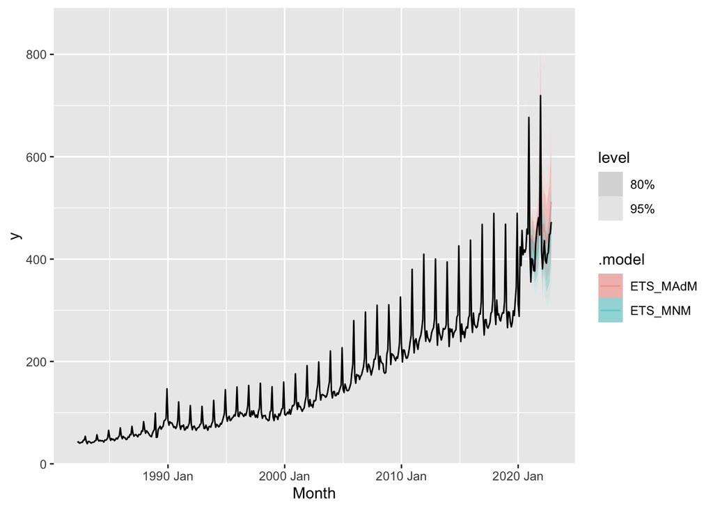

```r
fc <- ETS_train_fit %>% forecast(h=24)
fc %>% autoplot(myts, alpha=0.4)
```

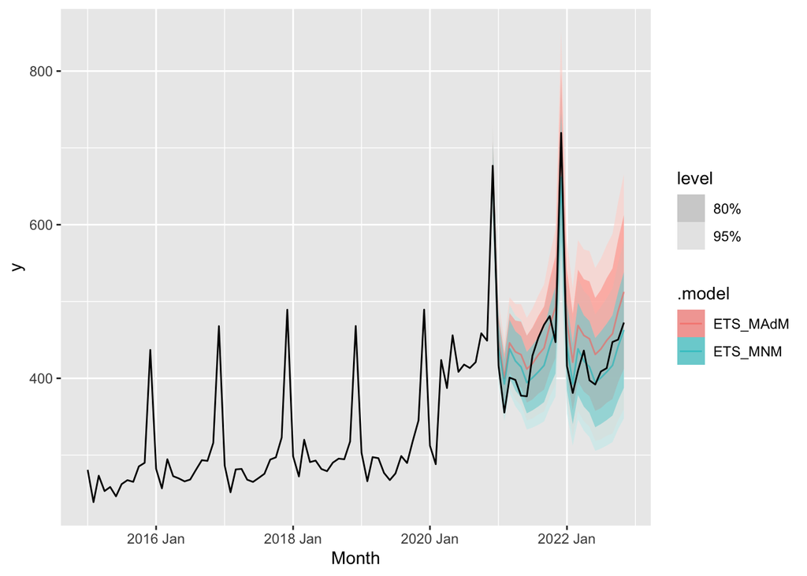

```r
fc %>% autoplot(filter(myts, year(Month)>=2015), alpha=0.6)
```

```r
fc %>% accuracy(myts) %>% select(.type,ME, RMSE, MAPE, MASE)
```

```
# A tibble: 2 × 5
  .type     ME  RMSE  MAPE  MASE
  <chr>  <dbl> <dbl> <dbl> <dbl>
1 Test  -25.4   37.2  8.22  2.84
2 Test    1.37  28.9  5.62  2.06
```

Comment on the results.

Marking guide:

- Plot the forecasts from both models over the data (with forecast intervals, for h=24). Zoom in if required or make sure visualisation is good enough (4m)
  - Slice the data 1m (if not 0)
  - Plot the forecasts from both models over the data 2m (if not 0, 1 if seperate plot)
  - Zoom in 1m (if not 0)
- Comment on the forecasts (1m)
- Comment on the forecast interval (2m)
- Predictive accuracy (printout +1m) + (interpret +1m) NO RMSE -1
- Bonus 2 marks if test sample comparison is performed and commented upon (-1 if MASE is not showing).

Expectation:

- Plot the forecasts as a continuation of the data.
- Comment on the forecasts. Are the forecasts plausible?
- Comment on the forecast intervals. How wide are the intervals? and why? can justify using the idea of perhaps autocorrelation still exist in the model.

Some students did not plot the forecast intervals and did not comment on them. It was clear in the question that you were asked to produce a graph with two sets of forecasts and forecast intervals, and comment on these.

Common errors:

- The explanation on prediction interval are wider for year 2023 compared to year 2022 will not be accepted as the comment on the forecast interval. As the time horizon gets larger, the forecast interval will be wider as well with some exceptional cases.
- The explanation on 95% prediction interval is wider than 80% is not accepted as a comment as well as this is a fact.

# Question 7

> Generate forecasts for the two years following the end of your sample using your chosen model. Plot them and briefly comment on these. (No more than 100 words). (4 marks)

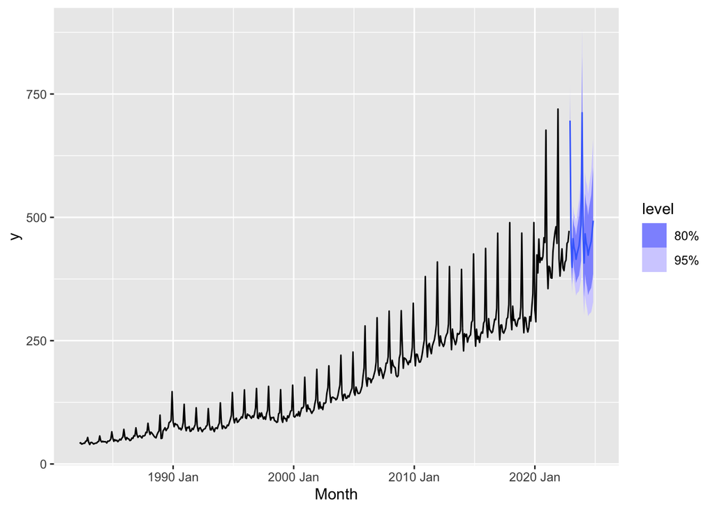

```r
ETS_MAdM %>% forecast() %>% autoplot(myts)
```

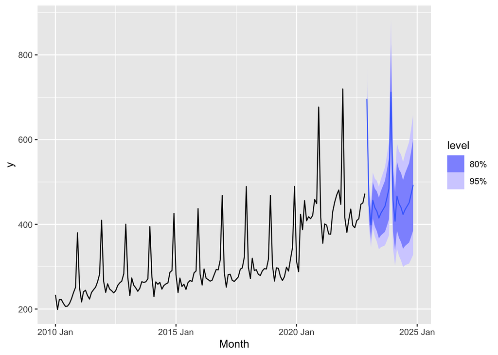

```r
ETS_MAdM %>% forecast() %>% autoplot(filter(myts, year(Month)>=2010))
```

Marks Breakdown:

- Plot of point forecast for h=24 in original unit. (2m)
- Comment on the forecasts and intervals (the width for my case here is important given the uncertainty). (2m)
- REMEMBER: Minus 1 overall if exceeding word limits.

Expectation:

- Plot the forecasts as a continuation of the data.
- Plot the forecasts on the original scale.
- Comment on the forecasts. Do they look plausible?

Common mistake:  
* Most of the explanation on prediction interval are due to the increase in time horizon.  
* Should relate the prediction interval with the potential left over pattern in the residual analysis.